# MD-HT3

Diego-Fabian

2024-03-04

## Análisis exploratorio

```r
library(dplyr)
if (!requireNamespace("Hmisc", quietly = TRUE)) {
  install.packages("Hmisc")
}
library(Hmisc)
datos  <- read.csv("train.csv")
```

```r
datos  <- read.csv("train.csv")
# Crear un dataframe con las variables, descripciones y tipos de variable
# Extraer los nombres de las variables
variables <- colnames(datos)
descripcion <- c("Identificador unico","Identifica el tipo de vivienda implicada en la venta.", "Identifica la clasificación general de zonificación de la venta.", "Pies lineales de la calle conectada a la propiedad.", "Tamaño del lote en pies cuadrados", "Tipo de calle de acceso a la propiedad", "Tipo de callejón de acceso a la propiedad", "Forma general de la propiedad", "Planitud de la propiedad", "Tipo de servicios disponibles", "Configuración de la parcela", "Pendiente de la propiedad", "Ubicaciones físicas dentro de los límites de la ciudad de Ames", "Proximidad a varias condiciones", "Proximidad a varias condiciones (si hay más de una)", "Tipo de vivienda", "Estilo de la vivienda", "Califica el material y el acabado general de la vivienda", "Valora el estado general de la vivienda", "Fecha de construcción original", "Fecha de remodelación (la misma que la fecha de construcción si no hay remodelaciones ni ampliaciones)", "Tipo de tejado", "Material del tejado", "Revestimiento exterior de la casa", "Revestimiento exterior de la casa (si hay más de un material)", "Tipo de revestimiento de mampostería", "Área de revestimiento de mampostería en pies cuadrados", "Evalúa la calidad del material en el exterior", "Evalúa el estado actual del material en el exterior", "Tipo de cimentación", "Evalúa la altura del sótano", "Evalúa el estado general del sótano", "Se refiere a las paredes de la planta baja o del jardín", "Calificación de la superficie acabada del sótano", "Pies cuadrados acabados tipo 1", "Calificación de la superficie acabada del sótano (si hay varios tipos)", "Pies cuadrados acabados de tipo 2", "Pies cuadrados sin terminar de la superficie del sótano", "Total de pies cuadrados de superficie del sótano", "Tipo de calefacción", "Calidad y estado de la calefacción", "Aire acondicionado central", "Sistema eléctrico", "Pies cuadrados del primer piso", "Pies cuadrados del segundo piso", "Pies cuadrados acabados de baja calidad (todas las plantas)", "Superficie habitable por encima del nivel del suelo en pies cuadrados", "Baños completos del sótano", "Sótano medio baño", "Baños completos sobre rasante", "Medios baños por encima del grado", "Dormitorios sobre rasante (NO incluye dormitorios en sótano)", "Cocinas sobre rasante", "Calidad de la cocina", "Total de habitaciones sobre rasante (no incluye baños)", "Funcionalidad de la vivienda (se asume como típica a menos que se justifiquen deducciones)", "Número de chimeneas", "Calidad de la chimenea", "Ubicación del garaje", "Año de construcción del garaje", "Acabado interior del garaje", "Tamaño del garaje en capacidad de coches", "Tamaño del garaje en metros cuadrados", "Calidad del garaje", "Estado del garaje", "Calzada pavimentada", "Superficie de cubierta de madera en pies cuadrados", "Superficie de porche abierto en pies cuadrados", "Superficie del porche cerrado en metros cuadrados", "Superficie del porche para tres estaciones en metros cuadrados", "Screen porch área en pies cuadrados", "Superficie de la piscina en metros cuadrados", "Calidad de la piscina", "Calidad de la valla", "Característica miscelánea no incluida en otras categorías", "Valor de la característica miscelánea", "Mes vendido (MM)", "Año de venta (AAAA)", "Tipo de venta", "Condición de venta", "Precio venta")

tipos_variables <- c("numérica", "categórica", "categórica", "numérica", "numérica", "categórica", "categórica", "categórica", "categórica", "categórica", "categórica", "categórica", "categórica", "categórica", "categórica", "categórica", "categórica", "numérica", "numérica", "numérica", "numérica", "categórica", "categórica", "categórica", "categórica", "categórica", "numérica", "categórica", "categórica", "categórica", "categórica", "categórica", "categórica", "categórica", "numérica", "categórica", "numérica", "numérica", "numérica", "categórica", "categórica", "categórica", "categórica", "numérica", "numérica", "numérica", "numérica", "numérica", "numérica", "numérica", "numérica", "numérica", "numérica", "categórica", "numérica", "categórica", "numérica", "categórica", "categórica", "numérica", "categórica", "numérica", "numérica", "categórica", "categórica", "categórica", "numérica", "numérica", "numérica", "numérica", "numérica", "numérica", "categórica", "categórica", "categórica", "numérica", "numérica", "numérica", "categórica", "categórica", "numérica")

# Crear el dataframe con la información
tabla_variables <- data.frame(Variable = variables,
                              Descripción = descripcion,
                              Tipo = tipos_variables )

print(tabla_variables)
```

```
##         Variable
## 1             Id
## 2     MSSubClass
## 3       MSZoning
## 4    LotFrontage
## 5        LotArea
## 6         Street
## 7          Alley
## 8       LotShape
## 9    LandContour
## 10     Utilities
## 11     LotConfig
## 12     LandSlope
## 13  Neighborhood
## 14    Condition1
```

[output cut: 231 more lines]

```r
# Campos donde se mide por calificaciones:
#       Ex  Excellent
#       Gd  Good
#       TA  Typical/Average
#       Fa  Fair
#       Po  Poor
#       NA  No

columnas_calificaciones <- c("Id", "ExterQual", "ExterCond", "Foundation", "BsmtQual", "BsmtCond", "HeatingQC", "KitchenQual", "FireplaceQu", "GarageQual", "GarageCond", "PoolQC")

datos_procesados_calificaciones <- datos[, columnas_calificaciones]

print(datos_procesados_calificaciones)
```

```
##        Id ExterQual ExterCond Foundation BsmtQual BsmtCond HeatingQC
## 1       1        Gd        TA      PConc       Gd       TA        Ex
## 2       2        TA        TA     CBlock       Gd       TA        Ex
## 3       3        Gd        TA      PConc       Gd       TA        Ex
## 4       4        TA        TA     BrkTil       TA       Gd        Gd
## 5       5        Gd        TA      PConc       Gd       TA        Ex
## 6       6        TA        TA       Wood       Gd       TA        Ex
## 7       7        Gd        TA      PConc       Ex       TA        Ex
## 8       8        TA        TA     CBlock       Gd       TA        Ex
## 9       9        TA        TA     BrkTil       TA       TA        Gd
## 10     10        TA        TA     BrkTil       TA       TA        Ex
## 11     11        TA        TA     CBlock       TA       TA        Ex
## 12     12        Ex        TA      PConc       Ex       TA        Ex
## 13     13        TA        TA     CBlock       TA       TA        TA
## 14     14        Gd        TA      PConc       Gd       TA        Ex
```

[output cut: 2907 more lines]

```r
datos <- datos %>%
  mutate(ExterCond = case_when(
    ExterCond == "Ex" ~ 5,
    ExterCond == "Gd" ~ 4,
    ExterCond == "TA" ~ 3,
    ExterCond == "Fa" ~ 2,
    ExterCond == "Po" ~ 1,
    TRUE ~ 0
  )) %>%
    mutate(ExterQual = case_when(
    ExterQual == "Ex" ~ 5,
    ExterQual == "Gd" ~ 4,
    ExterQual == "TA" ~ 3,
    ExterQual == "Fa" ~ 2,
    ExterQual == "Po" ~ 1,
    TRUE ~ 0
  )) %>%
  mutate(Foundation = case_when(
    Foundation == "BrkTil" ~ 6,
    Foundation == "CBlock" ~ 5,
    Foundation == "PConc" ~ 4,
    Foundation == "Slab" ~ 3,
    Foundation == "Stone" ~ 2,
    Foundation == "Wood" ~ 1,
    TRUE ~ NA_real_
  )) %>%
  mutate(BsmtQual = case_when(
    BsmtQual == "Ex" ~ 5,
    BsmtQual == "Gd" ~ 4,
    BsmtQual == "TA" ~ 3,
    BsmtQual == "Fa" ~ 2,
    BsmtQual == "Po" ~ 1,
    TRUE ~ 0
  ))%>%
  mutate(BsmtCond = case_when(
    BsmtCond == "Ex" ~ 5,
    BsmtCond == "Gd" ~ 4,
    BsmtCond == "TA" ~ 3,
    BsmtCond == "Fa" ~ 2,
    BsmtCond == "Po" ~ 1,
    TRUE ~ 0
  ))%>%
    mutate(BsmtExposure = case_when(
    BsmtExposure == "Ex" ~ 5,
    BsmtExposure == "Gd" ~ 4,
    BsmtExposure == "TA" ~ 3,
    BsmtExposure == "Fa" ~ 2,
    BsmtExposure == "Po" ~ 1,
    TRUE ~ 0
  ))%>%
    mutate(Heating = case_when(
    Heating == "Floor" ~ 6,
    Heating == "GasA" ~ 5,
    Heating == "GasW" ~ 4,
    Heating == "Grav" ~ 3,
    Heating == "OthW" ~ 2,
    Heating == "Wall" ~ 1,
    TRUE ~ 0
  ))%>%
   mutate(CentralAir = case_when(
    CentralAir == "Y" ~ 1,
    TRUE ~ 0
  ))%>%
   mutate(Heating = case_when(
    Heating == "Floor" ~ 6,
    Heating == "GasA" ~ 5,
    Heating == "GasW" ~ 4,
    Heating == "Grav" ~ 3,
    Heating == "OthW" ~ 2,
    Heating == "Wall" ~ 1,
    TRUE ~ 0
  ))%>%
  mutate(Electrical = case_when(
    Electrical == "SBrkr" ~ 5,
    Electrical == "FuseA" ~ 4,
    Electrical == "FuseF" ~ 3,
    Electrical == "FuseP" ~ 2,
    Electrical == "Mix" ~ 1,
    TRUE ~ 0
  ))%>%
  mutate(KitchenQual = case_when(
    KitchenQual == "Ex" ~ 5,
    KitchenQual == "Gd" ~ 4,
    KitchenQual == "TA" ~ 3,
    KitchenQual == "Fa" ~ 2,
    KitchenQual == "Po" ~ 1,
    TRUE ~ 0
  ))%>%
  mutate(FireplaceQu = case_when(
    FireplaceQu == "Ex" ~ 5,
    FireplaceQu == "Gd" ~ 4,
    FireplaceQu == "TA" ~ 3,
    FireplaceQu == "Fa" ~ 2,
    FireplaceQu == "Po" ~ 1,
    TRUE ~ 0
  ))%>%
  mutate(GarageQual = case_when(
    GarageQual == "Ex" ~ 5,
    GarageQual == "Gd" ~ 4,
    GarageQual == "TA" ~ 3,
    GarageQual == "Fa" ~ 2,
    GarageQual == "Po" ~ 1,
    TRUE ~ 0
  ))%>%
  mutate(GarageCond = case_when(
    GarageCond == "Ex" ~ 5,
    GarageCond == "TA" ~ 3,
    GarageCond == "Fa" ~ 2,
    GarageCond == "Po" ~ 1,
    TRUE ~ 0
  ))%>%
  mutate(PoolQC = case_when(
    PoolQC == "Ex" ~ 5,
    PoolQC == "Gd" ~ 4,
    PoolQC == "TA" ~ 3,
    PoolQC == "Fa" ~ 2,
    PoolQC == "Po" ~ 1,
    TRUE ~ 0
  ))
```

### Verificacion de valores nulos

```r
# Calcula la suma de valores nulos por columna
nullValues <- sapply(datos, function(x) sum(is.na(x)))

# Filtra las columnas que tienen más de 0 valores nulos
nullValues <- nullValues[nullValues > 0]

# Imprime las columnas con valores nulos y su respectiva cantidad
cat("Columnas con valores NaN:\n")
```

```
## Columnas con valores NaN:
```

```r
print(nullValues)
```

```
##  LotFrontage        Alley   MasVnrType   MasVnrArea BsmtFinType1 BsmtFinType2
##          259         1369            8            8           37           38
##   GarageType  GarageYrBlt GarageFinish        Fence  MiscFeature
##           81           81           81         1179         1406
```

Se muestran que los siguientes campos tienen valores nulos, se puede observar que esto es preodminante en: MiscFeature, Fence, Alley. Se debe considerar si estos representan algo de valor o deben ser ignorados en el posterior analisis.

### Correlación y relación

```r
# Extraemos la columna 'SalePrice' del dataframe
salePriceData <- datos$SalePrice

# Creamos una copia del dataframe excluyendo la columna 'Id' y seleccionando solo las columnas numéricas
datos_numerical_cp <- datos %>%
  dplyr::select(-Id) %>%
  dplyr::select_if(is.numeric)

# Iteramos sobre las columnas del dataframe numérico
for (col in colnames(datos_numerical_cp)) {
  colData <- datos_numerical_cp[[col]]

  # Suprimimos los mensajes de advertencia alrededor de cor.test
  corr_test <- suppressWarnings(cor.test(salePriceData, colData, method = "spearman"))

  # Extraemos el coeficiente de correlación de Spearman del resultado del test
  corr <- corr_test$estimate

  # Verificamos si la correlación es mayor o igual a 0.45
  if (!is.na(corr) && corr >= 0.45) {
    cat(sprintf("'%s' coeficiente de correlación spearman : %f\n", col, corr))
  }
}
```

```
## 'LotArea' coeficiente de correlación spearman : 0.456461
## 'OverallQual' coeficiente de correlación spearman : 0.809829
## 'YearBuilt' coeficiente de correlación spearman : 0.652682
## 'YearRemodAdd' coeficiente de correlación spearman : 0.571159
## 'ExterQual' coeficiente de correlación spearman : 0.684014
## 'BsmtQual' coeficiente de correlación spearman : 0.678026
## 'TotalBsmtSF' coeficiente de correlación spearman : 0.602725
## 'X1stFlrSF' coeficiente de correlación spearman : 0.575408
## 'GrLivArea' coeficiente de correlación spearman : 0.731310
## 'FullBath' coeficiente de correlación spearman : 0.635957
## 'KitchenQual' coeficiente de correlación spearman : 0.672849
## 'TotRmsAbvGrd' coeficiente de correlación spearman : 0.532586
## 'Fireplaces' coeficiente de correlación spearman : 0.519247
## 'FireplaceQu' coeficiente de correlación spearman : 0.537602
## 'GarageYrBlt' coeficiente de correlación spearman : 0.593788
## 'GarageCars' coeficiente de correlación spearman : 0.690711
## 'GarageArea' coeficiente de correlación spearman : 0.649379
## 'OpenPorchSF' coeficiente de correlación spearman : 0.477561
## 'SalePrice' coeficiente de correlación spearman : 1.000000
```

Se considera unicamente los datos que posean un resultado superior a 0.6 ya que esto nos indica una correlación fuerte. Se utiliza este tipo de relación ya que no poseen una distribución normal como tal.

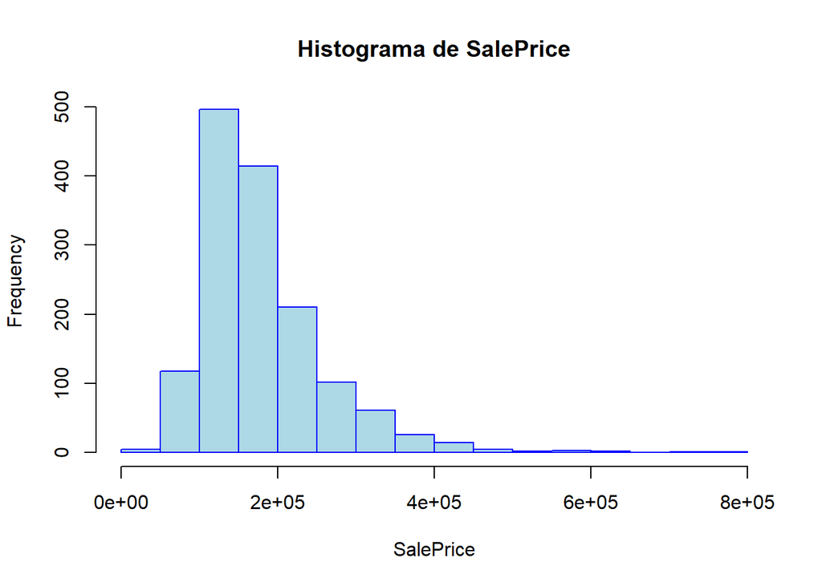

```r
hist(datos$SalePrice, main = "Histograma de SalePrice", xlab = "SalePrice", border = "blue", col = "lightblue")
```

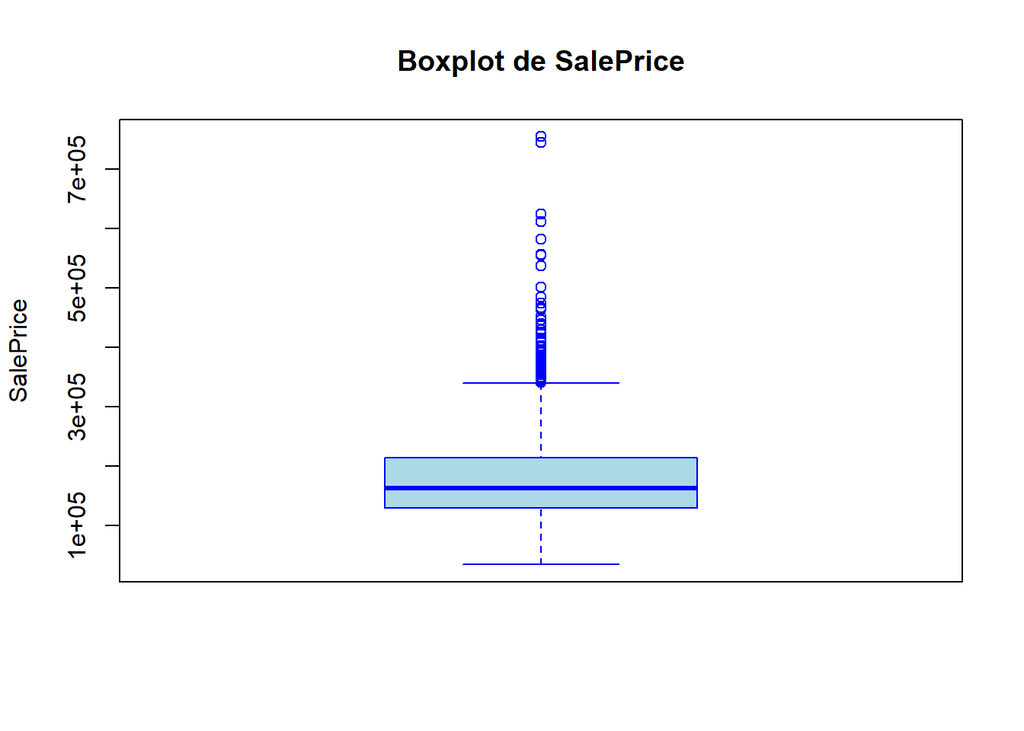

```r
#Diagrama caja y bigotes
boxplot(datos$SalePrice, main = "Boxplot de SalePrice", ylab = "SalePrice", col = "lightblue", border = "blue")
```

[figure not shown]

```r
hist(datos$LotArea, main = "Histograma de SalePrice", xlab = "LotArea", border = "blue", col = "lightblue")
```

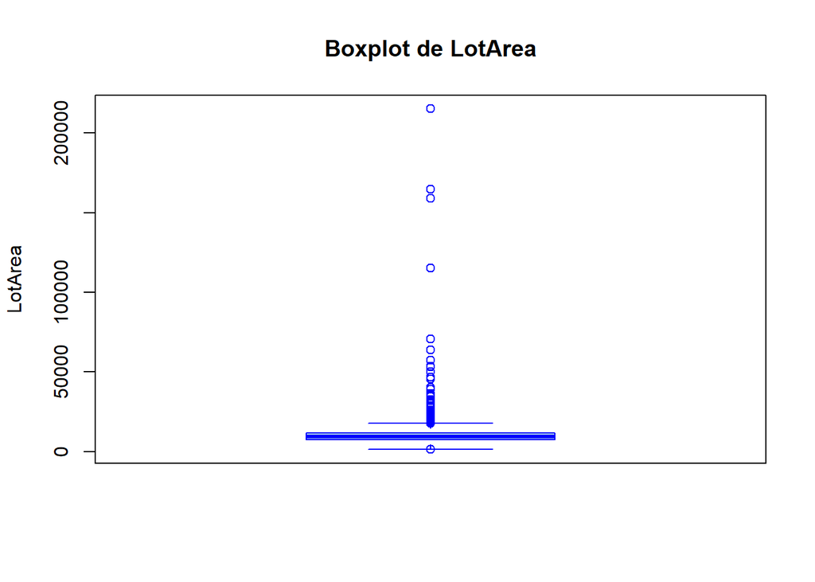

```r
#Diagrama caja y bigotes
boxplot(datos$LotArea, main = "Boxplot de LotArea", ylab = "LotArea", col = "lightblue", border = "blue")
```

[figure not shown]

```r
hist(datos$OverallQual, main = "Histograma de SalePrice", xlab = "OverallQual", border = "blue", col = "lightblue")
```

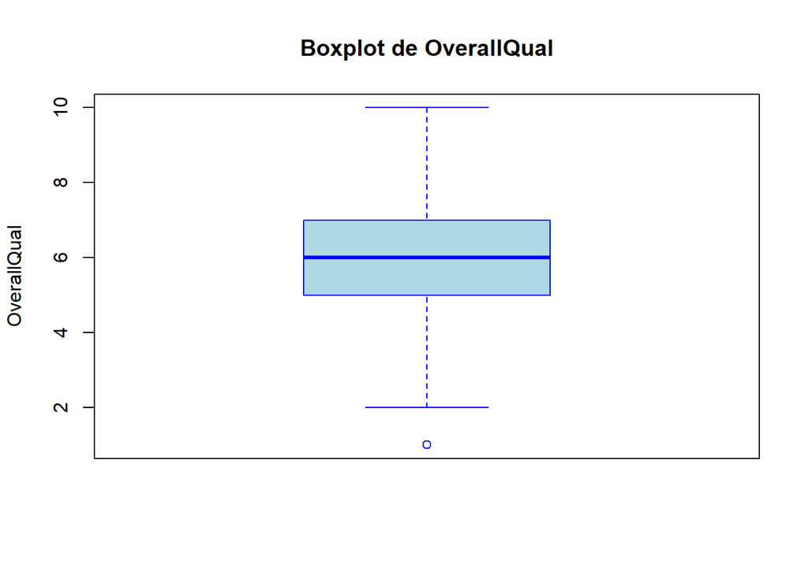

```r
#Diagrama caja y bigotes
boxplot(datos$OverallQual, main = "Boxplot de OverallQual", ylab = "OverallQual", col = "lightblue", border = "blue")
```

###Llenado de data para uso en modelos

```r
# Identificar las columnas numéricas
numeric_features <- sapply(datos, is.numeric)

# Rellenar los valores NAN's con 0 en las columnas numéricas
datos[, numeric_features] <- lapply(datos[, numeric_features, drop = FALSE], function(x) ifelse(is.na(x), 0, x))

#Identificar los nombres de las columnas categóricas
nombres_categoricos <- names(datos)[sapply(datos, function(x) !is.numeric(x))]

#Rellenar los valores NAN's con "NA" en las columnas categóricas
datos[, nombres_categoricos] <- lapply(datos[, nombres_categoricos, drop = FALSE], function(x) ifelse(is.na(x), "NA", x))

#Reemplazar "NA" con 0 en columnas categóricas
datos[, nombres_categoricos] <- lapply(datos[, nombres_categoricos, drop = FALSE], function(x) replace(x, x == "NA", 0))
```

```r
no_null_counts <- colSums(!is.na(datos))
print(no_null_counts)
```

```
##            Id    MSSubClass      MSZoning   LotFrontage       LotArea
##          1460          1460          1460          1460          1460
##        Street         Alley      LotShape   LandContour     Utilities
##          1460          1460          1460          1460          1460
##     LotConfig     LandSlope  Neighborhood    Condition1    Condition2
##          1460          1460          1460          1460          1460
##      BldgType    HouseStyle   OverallQual   OverallCond     YearBuilt
##          1460          1460          1460          1460          1460
##  YearRemodAdd     RoofStyle      RoofMatl   Exterior1st   Exterior2nd
##          1460          1460          1460          1460          1460
##    MasVnrType    MasVnrArea     ExterQual     ExterCond    Foundation
##          1460          1460          1460          1460          1460
##      BsmtQual      BsmtCond  BsmtExposure  BsmtFinType1    BsmtFinSF1
##          1460          1460          1460          1460          1460
##  BsmtFinType2    BsmtFinSF2     BsmtUnfSF   TotalBsmtSF       Heating
##          1460          1460          1460          1460          1460
##     HeatingQC    CentralAir    Electrical     X1stFlrSF     X2ndFlrSF
##          1460          1460          1460          1460          1460
##  LowQualFinSF     GrLivArea  BsmtFullBath  BsmtHalfBath      FullBath
##          1460          1460          1460          1460          1460
##      HalfBath  BedroomAbvGr  KitchenAbvGr   KitchenQual  TotRmsAbvGrd
##          1460          1460          1460          1460          1460
##    Functional    Fireplaces   FireplaceQu    GarageType   GarageYrBlt
##          1460          1460          1460          1460          1460
##  GarageFinish    GarageCars    GarageArea    GarageQual    GarageCond
##          1460          1460          1460          1460          1460
##    PavedDrive    WoodDeckSF   OpenPorchSF EnclosedPorch    X3SsnPorch
##          1460          1460          1460          1460          1460
##   ScreenPorch      PoolArea        PoolQC         Fence   MiscFeature
##          1460          1460          1460          1460          1460
##       MiscVal        MoSold        YrSold      SaleType SaleCondition
##          1460          1460          1460          1460          1460
##     SalePrice
##          1460
```

###Seleccion de las columnas

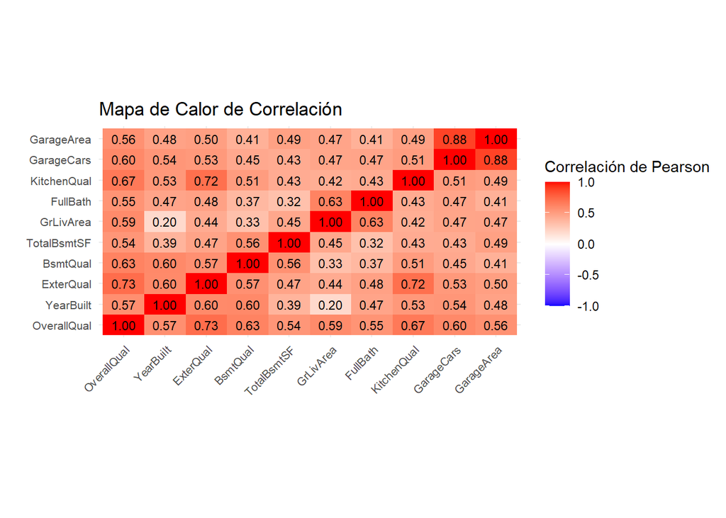

```r
library(ggplot2)
library(reshape2)
# Definir las columnas seleccionadas basadas en su correlación de Spearman > 0.6
selected_columns <- c("OverallQual", "YearBuilt", "ExterQual", "BsmtQual", "TotalBsmtSF",
                      "GrLivArea", "FullBath", "KitchenQual", "GarageCars", "GarageArea")

# Seleccionar las columnas del dataframe
selected_predictors <- datos[selected_columns]

# Calcular la matriz de correlación
predictors_corr <- cor(selected_predictors, use = "complete.obs", method = "pearson")

# Transformar la matriz de correlación para la visualización
melted_corr <- melt(predictors_corr)

# Crear el mapa de calor, ajustar el tema y añadir los textos de correlación
ggplot(data = melted_corr, aes(x = Var1, y = Var2, fill = value)) +
  geom_tile() +  # Dibuja los cuadros del mapa de calor
  geom_text(aes(label = sprintf("%.2f", value)), size = 3, color = "black") +  # Añade los valores de correlación
  scale_fill_gradient2(low = "blue", high = "red", mid = "white",
                       midpoint = 0, limit = c(-1,1), space = "Lab",
                       name="Correlación de Pearson") +
  theme_minimal() +
  theme(axis.text.x = element_text(angle = 45, vjust = 1, hjust = 1, size = 8),  # Reduce el tamaño del texto del eje x
        axis.text.y = element_text(size = 8)) +  # Reduce el tamaño del texto del eje y
  labs(x = "", y = "", title = "Mapa de Calor de Correlación") +
  coord_fixed(ratio = 1 / (length(selected_columns) / 5))  # Ajusta el tamaño de los cuadros
```

###Seleccion de los mejores datos en la correlacion

```r
mejores_Datos <- datos %>% dplyr::select(OverallQual, YearBuilt,  KitchenQual, GarageArea, FullBath, GrLivArea, GarageCars, X1stFlrSF, FullBath, TotRmsAbvGrd, FireplaceQu, MasVnrArea)

head(mejores_Datos)
```

```
##   OverallQual YearBuilt KitchenQual GarageArea FullBath GrLivArea GarageCars
## 1           7      2003           4        548        2      1710          2
## 2           6      1976           3        460        2      1262          2
## 3           7      2001           4        608        2      1786          2
## 4           7      1915           4        642        1      1717          3
## 5           8      2000           4        836        2      2198          3
## 6           5      1993           3        480        1      1362          2
##   X1stFlrSF TotRmsAbvGrd FireplaceQu MasVnrArea
## 1       856            8           0        196
## 2      1262            6           3          0
## 3       920            6           3        162
## 4       961            7           4          0
## 5      1145            9           3        350
## 6       796            5           0          0
```

#Modelado

###Regresion Lineal

```r
library(caTools)  # Para dividir los datos
library(MASS)     # Para AIC y BIC si es necesario
y <- datos$SalePrice
X <- scale(mejores_Datos)

# Convertir la matriz escalada de nuevo a un dataframe
X_df <- as.data.frame(X)

# Dividir los datos en conjuntos de entrenamiento y prueba
set.seed(42)  # Para reproducibilidad
split <- sample.split(y, SplitRatio = 0.8)
X_train <- X_df[split, ]
X_test <- X_df[!split, ]
y_train <- y[split]
y_test <- y[!split]

# Ajustar el modelo de regresión lineal
model <- lm(y_train ~ ., data = X_train)

# Realizar predicciones en el conjunto de prueba
y_pred <- predict(model, newdata = X_test)

# Calcular métricas de evaluación
explained_variance <- summary(model)$r.squared
mean_squared_error <- mean((y_test - y_pred)^2)
r2 <- summary(model)$r.squared
mean_absolute_error <- mean(abs(y_test - y_pred))
mse <- mean_squared_error
aic <- AIC(model)
bic <- BIC(model)

# Imprimir las métricas de evaluación
cat("Explained Variance:", explained_variance, "\n")
```

```
## Explained Variance: 0.8114168
```

```r
cat("Mean Squared Error:", mean_squared_error, "\n")
```

```
## Mean Squared Error: 1984578743
```

```r
cat("R2:", r2, "\n")
```

```
## R2: 0.8114168
```

```r
cat("Mean Absolute Error:", mean_absolute_error, "\n")
```

```
## Mean Absolute Error: 21601.67
```

```r
cat("Mean Squared Error:", mse, "\n")
```

```
## Mean Squared Error: 1984578743
```

```r
cat("AIC:", aic, "\n")
```

```
## AIC: 29985.43
```

```r
cat("BIC:", bic, "\n")
```

```
## BIC: 30052.21
```

##Análisis residual

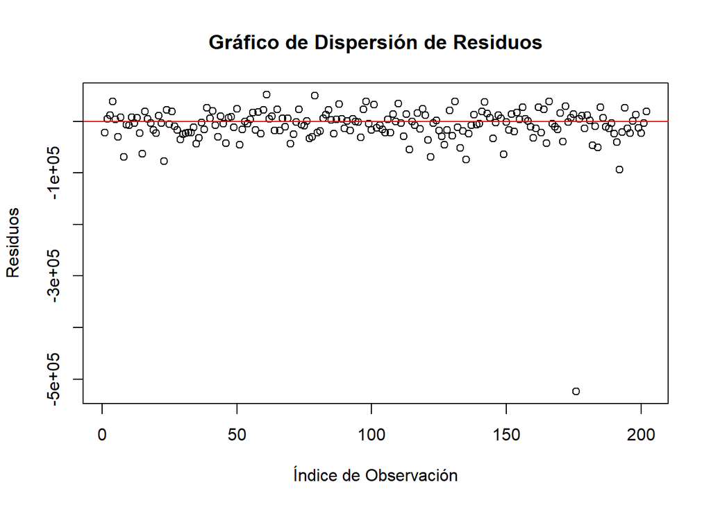

```r
residuos <- y_test - y_pred
# Gráfico de dispersión de residuos
plot(residuos, type = "p", main = "Gráfico de Dispersión de Residuos",
     xlab = "Índice de Observación", ylab = "Residuos")
abline(h = 0, col = "red")  # Línea horizontal en 0 para referencia
```

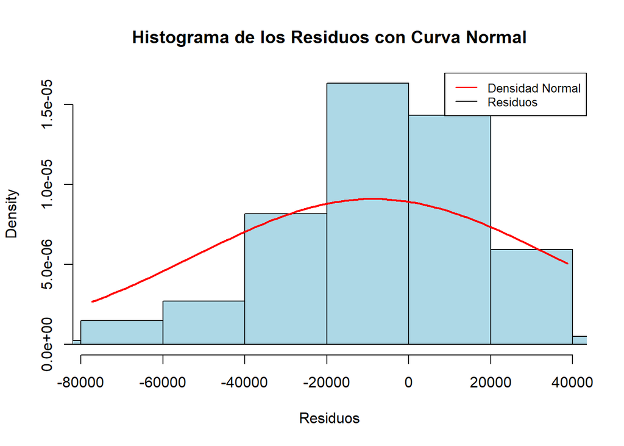

```r
# Histograma de los residuos
# Establecer límites para el eje x excluyendo el dato atípico
lim_x <- quantile(residuos, c(0.01, 0.99))

# Histograma de los residuos con límites en el eje x
hist(residuos, breaks = 30, xlim = lim_x, freq = FALSE,
     main = "Histograma de los Residuos con Curva Normal",
     xlab = "Residuos", col = "lightblue")

# Calcular la media y la desviación estándar de los residuos
media_residuos <- mean(residuos)
sd_residuos <- sd(residuos)

# Superponer una curva normal
curve(dnorm(x, mean = media_residuos, sd = sd_residuos),
      col = "red", lwd = 2, add = TRUE, xlim = lim_x)

# Añadir leyenda
legend("topright", legend = c("Densidad Normal", "Residuos"),
       col = c("red", "black"), lty = 1:1, cex = 0.8)
```

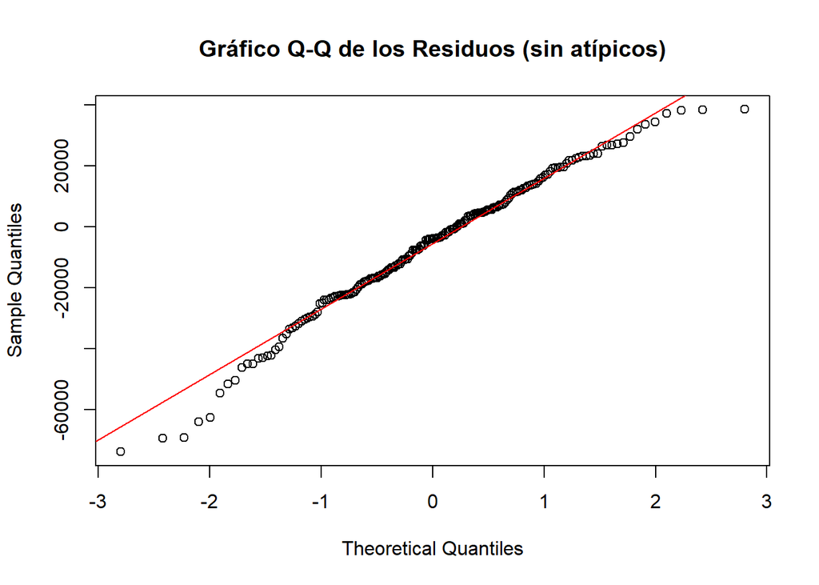

```r
# Gráfico Q-Q de los residuos
# Filtrar los residuos para excluir valores extremos
lim_qq <- quantile(residuos, c(0.01, 0.99))  # Establecer límites basados en cuantiles
residuos_filtrados <- residuos[residuos > lim_qq[1] & residuos < lim_qq[2]]

# Gráfico Q-Q de los residuos filtrados
qqnorm(residuos_filtrados, main = "Gráfico Q-Q de los Residuos (sin atípicos)")
qqline(residuos_filtrados, col = "red")  # Añadir línea Q-Q
```

```r
# Prueba de Shapiro-Wilk para normalidad de los residuos
shapiro.test(residuos)
```

```
##
##  Shapiro-Wilk normality test
##
## data:  residuos
## W = 0.50238, p-value < 2.2e-16
```

Las distintas graficas nos muestran que los residuos siguen una distribucion normal pero al poseer un valor W bajo y un valor p extremadamente bajo sugiere que los residuos de tu modelo no se distribuyen normalmente. Esto puede ser un indicativo de varios problemas potenciales con el modelo y que poseemos algunos valores atípicos distorcionando así la distribución de los residuos

### Modelo Lasso

```r
library(glmnet)
library(Metrics)
# Ajustar el modelo LASSO con validación cruzada
set.seed(42)  # Para reproducibilidad
cv_lasso <- cv.glmnet(x = X, y = y, alpha = 1, family = "gaussian")

# Ver el valor lambda que minimiza el error de validación cruzada
best_lambda <- cv_lasso$lambda.min
print(best_lambda)
```

```
## [1] 1262.12
```

```r
# Crear el modelo LASSO usando el mejor lambda
lasso_model <- glmnet(x = X, y = y, alpha = 1, lambda = best_lambda, family = "gaussian")

# Ver los coeficientes del modelo
coef(lasso_model)
```

```
## 12 x 1 sparse Matrix of class "dgCMatrix"
##                      s0
## (Intercept)  180921.196
## OverallQual   22948.386
## YearBuilt      6617.508
## KitchenQual   11952.643
## GarageArea     3414.938
## FullBath          .
## GrLivArea     21210.547
## GarageCars     5293.783
## X1stFlrSF      9694.476
## TotRmsAbvGrd      .
## FireplaceQu    4583.144
## MasVnrArea     5529.071
```

Los que poseen valores nulos no contribuyen en nada a la variable dependiente para poder predecirla por lo que FullBath y TotRmsAbvGrd no son relevantes para el modelo en el contexto de las otras variables. La variable que mejor predice el valor de SalePrice es la OverallQuallya que posee el coeficiente con mayor valor.

```r
# Realizar predicciones con el modelo LASSO
y_pred_lasso <- predict(lasso_model, newx = as.matrix(X_test), s = best_lambda, type = "response")

explained_variance_lasso <- cor(y_test, y_pred_lasso)^2

# Asegurarse de que no haya valores negativos
if(any(y_test <= 0) | any(y_pred_lasso <= 0)){
  stop("MSLE no puede ser calculado para valores negativos o cero.")
}

mean_squared_log_error_lasso <- mean((log(y_pred_lasso + 1) - log(y_test + 1))^2)



# Calcular el R2
r2_lasso <- cor(y_test, y_pred_lasso)^2

# Calcular el Mean Squared Error (MSE)
mse_lasso <- mse(y_test, y_pred_lasso)

# Calcular el Mean Absolute Error (MAE)
mae_lasso <- mae(y_test, y_pred_lasso)

# Calcular AIC (No está directamente disponible para modelos glmnet, así que se usa una aproximación)
n <- length(y_test)  # Número de observaciones en el conjunto de prueba
p <- sum(coef(lasso_model, s = best_lambda) != 0)  # Número de predictores seleccionados por LASSO
aic_lasso <- n * log(mse_lasso) + 2 * p

# Calcular BIC (Usando la misma aproximación)
bic_lasso <- n * log(mse_lasso) + log(n) * p

# Imprimir las métricas de evaluación
cat("Explained Variance LASSO:", explained_variance_lasso, "\n")
```

```
## Explained Variance LASSO: 0.6662819
```

```r
cat("Mean Squared Log Error (MSLE) LASSO:", mean_squared_log_error_lasso, "\n")
```

```
## Mean Squared Log Error (MSLE) LASSO: 0.04100981
```

```r
cat("R2 LASSO:", r2_lasso, "\n")
```

```
## R2 LASSO: 0.6662819
```

```r
cat("Mean Squared Error (MSE) LASSO:", mse_lasso, "\n")
```

```
## Mean Squared Error (MSE) LASSO: 1408570159
```

```r
cat("Mean Absolute Error (MAE) LASSO:", mae_lasso, "\n")
```

```
## Mean Absolute Error (MAE) LASSO: 20084.23
```

```r
cat("AIC LASSO:", aic_lasso, "\n")
```

```
## AIC LASSO: 4275.3
```

```r
cat("BIC LASSO:", bic_lasso, "\n")
```

```
## BIC LASSO: 4308.383
```

##Análisis residual

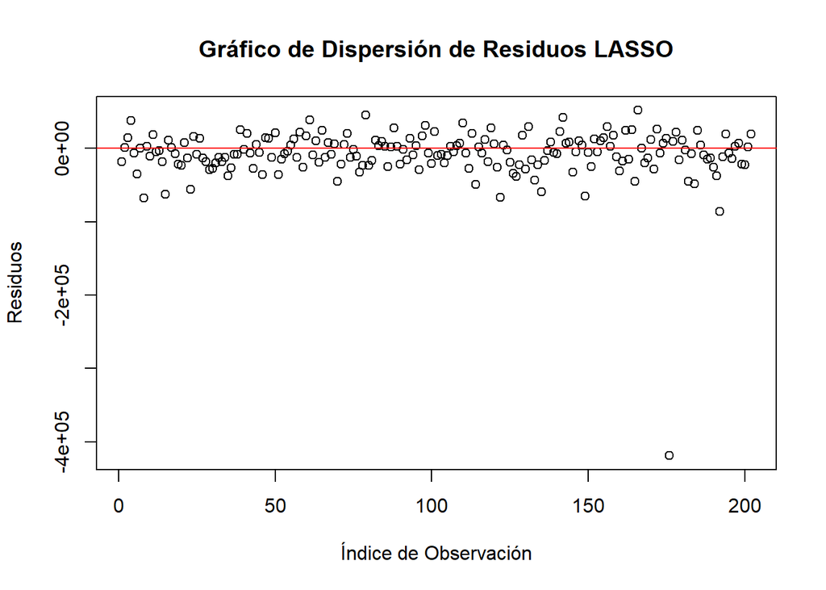

```r
# Realizar predicciones con el modelo LASSO
y_pred_lasso <- predict(lasso_model, newx = as.matrix(X_test), s = best_lambda, type = "response")

# Calcular los residuos
residuos <- y_test - y_pred_lasso
# Gráfico de dispersión de residuos
plot(residuos, type = "p", main = "Gráfico de Dispersión de Residuos LASSO",
     xlab = "Índice de Observación", ylab = "Residuos")
abline(h = 0, col = "red")  # Línea horizontal en 0 para referencia
```

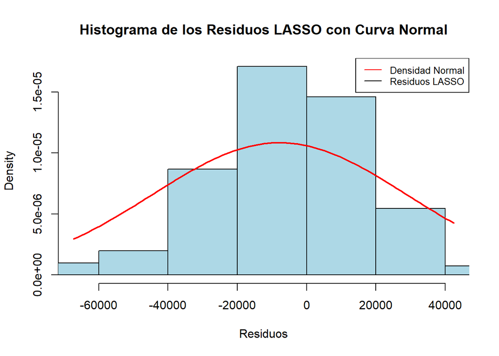

```r
# Establecer límites para el eje x excluyendo el dato atípico
lim_x <- quantile(residuos, c(0.01, 0.99))

# Histograma de los residuos con límites en el eje x
hist(residuos, breaks = 30, xlim = lim_x, freq = FALSE,
     main = "Histograma de los Residuos LASSO con Curva Normal",
     xlab = "Residuos", col = "lightblue")

# Superponer una curva normal
media_residuos <- mean(residuos)
sd_residuos <- sd(residuos)
curve(dnorm(x, mean = media_residuos, sd = sd_residuos),
      col = "red", lwd = 2, add = TRUE, xlim = lim_x)

# Añadir leyenda
legend("topright", legend = c("Densidad Normal", "Residuos LASSO"),
       col = c("red", "black"), lty = 1:1, cex = 0.8)
```

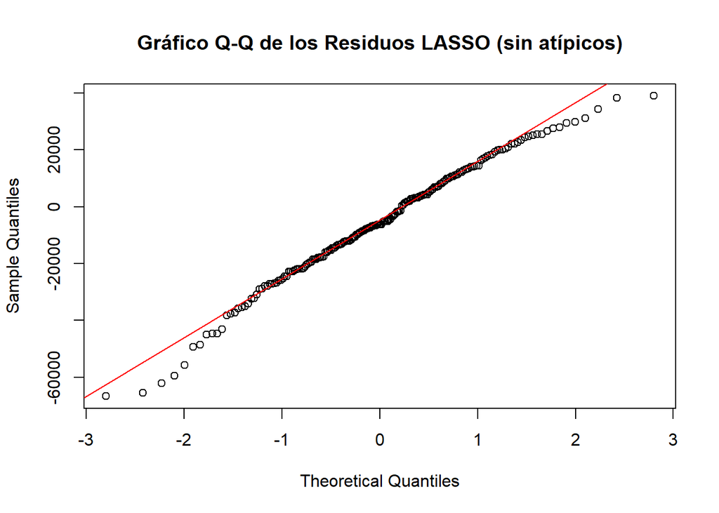

```r
# Filtrar los residuos para excluir valores extremos
lim_qq <- quantile(residuos, c(0.01, 0.99))
residuos_filtrados <- residuos[residuos > lim_qq[1] & residuos < lim_qq[2]]

# Gráfico Q-Q de los residuos filtrados
qqnorm(residuos_filtrados, main = "Gráfico Q-Q de los Residuos LASSO (sin atípicos)")
qqline(residuos_filtrados, col = "red")
```

```r
# Prueba de Shapiro-Wilk para normalidad de los residuos
```

[output not shown]

El coeficiente de determinación r^2 de 0.666 indica que el modelo puede explicar aproximadamente el 66.6% de la variabilidad en los datos, lo cual es un rendimiento razonablemente bueno. Sin embargo, una tercera parte de la variabilidad no está siendo capturada por el modelo.

## Modelo de Ridge

```r
library(Metrics)
library(glmnet)
library(caTools)  # Para dividir los datos
library(ggplot2)
library(ggpubr)

# Preparación de los datos
y <- datos$SalePrice
X <- scale(mejores_Datos)

# Convertir la matriz escalada de nuevo a un dataframe
X_df <- as.data.frame(X)

# Dividir los datos en conjuntos de entrenamiento y prueba
set.seed(42)  # Para reproducibilidad
split <- sample.split(y, SplitRatio = 0.8)
X_train <- X_df[split, ]
X_test <- X_df[!split, ]
y_train <- y[split]
y_test <- y[!split]

# Ajuste del modelo Ridge con validación cruzada
x <- as.matrix(X_train)  # Convertir a matriz
y <- y_train
cv_ridge_model <- cv.glmnet(x, y, alpha=0)

# Lambda óptimo basado en la validación cruzada
lambda_optimo <- cv_ridge_model$lambda.min

# Predicciones con lambda óptimo
x_test <- as.matrix(X_test)  # Convertir a matriz
y_pred_ridge <- predict(cv_ridge_model, s=lambda_optimo, newx=x_test)

# Evaluación
explained_variance_ridge <- 1 - var(y_test - y_pred_ridge) / var(y_test)
mse_ridge <- mse(y_test, y_pred_ridge)

# Calcula manualmente el R^2
ss_res <- sum((y_test - y_pred_ridge)^2)  # Suma de cuadrados de los residuos
ss_tot <- sum((y_test - mean(y_test))^2)  # Suma total de cuadrados
r2_ridge <- 1 - (ss_res / ss_tot)

mae_ridge <- mae(y_test, y_pred_ridge)

# Imprimir métricas de evaluación
cat("Lambda óptimo:", lambda_optimo, "\n")
```

```
## Lambda óptimo: 6601.59
```

```r
cat("Explained Variance:", explained_variance_ridge, "\n")
```

```
## Explained Variance: 0.345851
```

```r
cat("Mean Squared Error:", mse_ridge, "\n")
```

```
## Mean Squared Error: 1727507954
```

```r
cat("R2:", r2_ridge, "\n")
```

```
## R2: 0.3166692
```

```r
cat("Mean Absolute Error:", mae_ridge, "\n")
```

```
## Mean Absolute Error: 20738.79
```

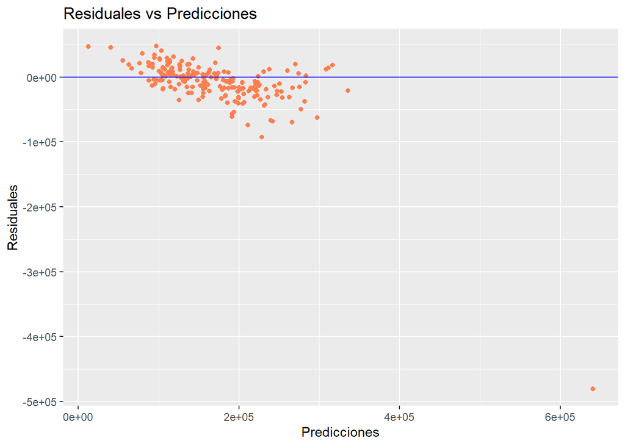

```r
# Análisis de Residuales
residuals_ridge <- y_test - y_pred_ridge

# Residuales vs Predicciones
ggplot() +
  geom_point(aes(x=y_pred_ridge, y=residuals_ridge), color='coral') +
  geom_hline(yintercept=0, color='blue') +
  ggtitle('Residuales vs Predicciones') +
  xlab('Predicciones') +
  ylab('Residuales')
```

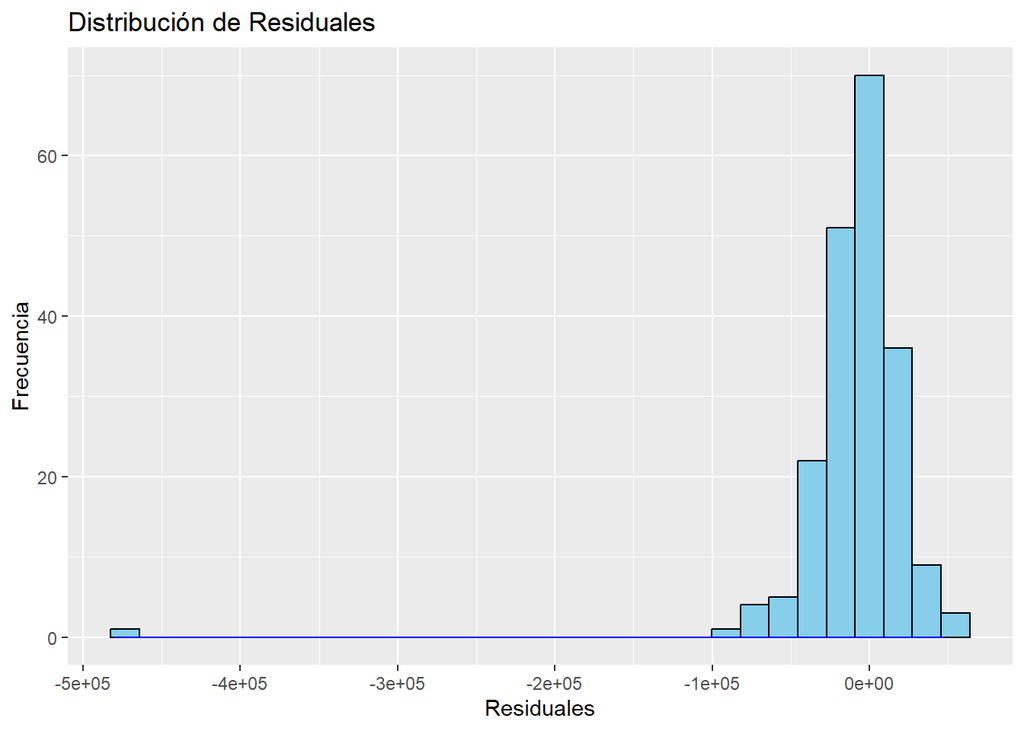

```r
# Distribución de Residuales
ggplot() +
  geom_histogram(aes(x=residuals_ridge), bins=30, fill='skyblue', color='black') +
  geom_density(aes(x=residuals_ridge, y=..density..), color='blue') +
  ggtitle('Distribución de Residuales') +
  xlab('Residuales') +
  ylab('Frecuencia')
```

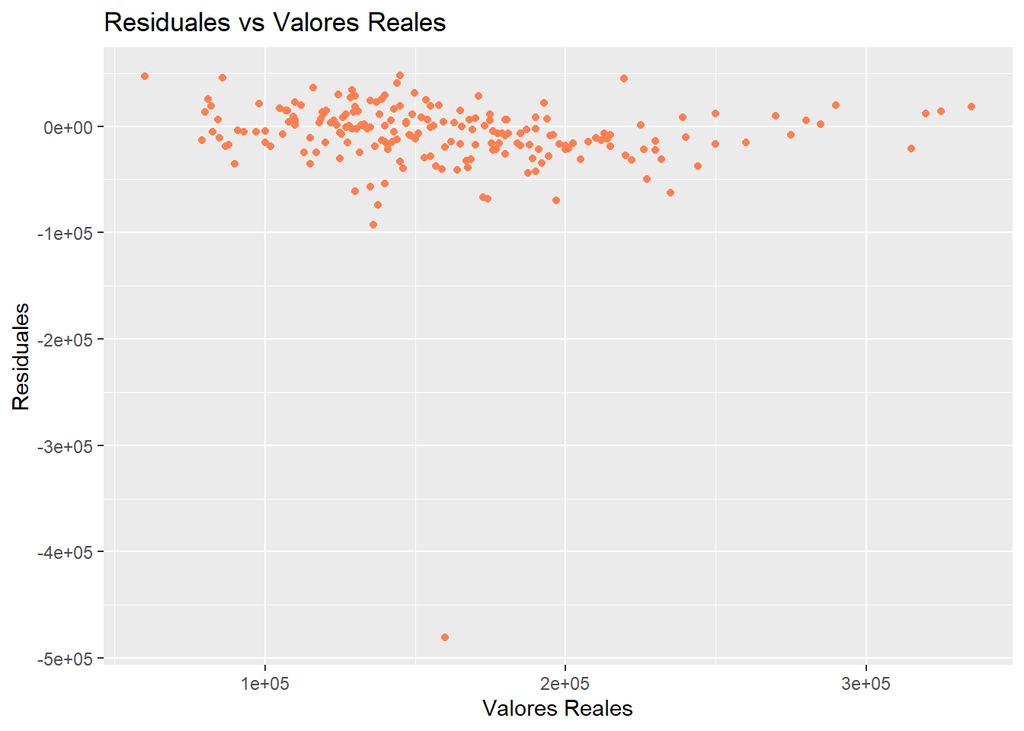

```r
# Residuales vs Valores Reales
ggplot() +
  geom_point(aes(x=y_test, y=residuals_ridge), color='coral') +
  ggtitle('Residuales vs Valores Reales') +
  xlab('Valores Reales') +
  ylab('Residuales')
```

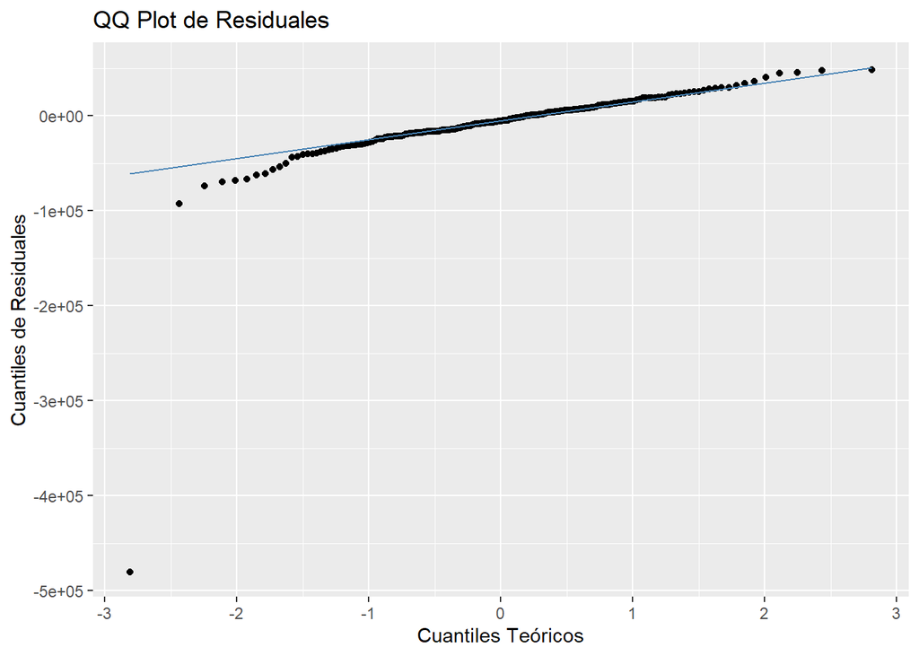

```r
library(ggplot2)

# Asegurarse de que los residuales están en el formato correcto
residuals_ridge <- as.numeric(y_test - y_pred_ridge)

# Crear un dataframe para los residuales
residuals_df <- data.frame(residuals = residuals_ridge)

# QQ Plot utilizando ggplot2
ggplot(residuals_df, aes(sample = residuals)) +
  stat_qq() +
  stat_qq_line(color = "steelblue") +
  ggtitle("QQ Plot de Residuales") +
  xlab("Cuantiles Teóricos") +
  ylab("Cuantiles de Residuales")
```

## Modelo de Elastic Net

```r
library(Metrics)
library(glmnet)
library(caTools)  # Para dividir los datos
library(ggplot2)
library(ggpubr)

# Preparación de los datos
y <- datos$SalePrice
X <- scale(mejores_Datos)

# Convertir la matriz escalada de nuevo a un dataframe
X_df <- as.data.frame(X)

# Dividir los datos en conjuntos de entrenamiento y prueba
set.seed(42)  # Para reproducibilidad
split <- sample.split(y, SplitRatio = 0.8)
X_train <- X_df[split, ]
X_test <- X_df[!split, ]
y_train <- y[split]
y_test <- y[!split]

# Ajuste del modelo Elastic Net con validación cruzada
x <- as.matrix(X_train)  # Convertir a matriz
y <- y_train
cv_elasticnet_model <- cv.glmnet(x, y, alpha=0.5)  # alpha ajustado para Elastic Net

# Lambda óptimo basado en la validación cruzada
lambda_optimo <- cv_elasticnet_model$lambda.min

# Predicciones con lambda óptimo
x_test <- as.matrix(X_test)  # Convertir a matriz
y_pred_elasticnet <- predict(cv_elasticnet_model, s=lambda_optimo, newx=x_test)

# Evaluación
explained_variance_elasticnet <- 1 - var(y_test - y_pred_elasticnet) / var(y_test)
mse_elasticnet <- mse(y_test, y_pred_elasticnet)

# Calcula manualmente el R^2
ss_res <- sum((y_test - y_pred_elasticnet)^2)  # Suma de cuadrados de los residuos
ss_tot <- sum((y_test - mean(y_test))^2)  # Suma total de cuadrados
r2_elasticnet <- 1 - (ss_res / ss_tot)

mae_elasticnet <- mae(y_test, y_pred_elasticnet)

# Imprimir métricas de evaluación
cat("Lambda óptimo:", lambda_optimo, "\n")
```

```
## Lambda óptimo: 1383.186
```

```r
cat("Explained Variance:", explained_variance_elasticnet, "\n")
```

```
## Explained Variance: 0.3089056
```

```r
cat("Mean Squared Error:", mse_elasticnet, "\n")
```

```
## Mean Squared Error: 1821999309
```

```r
cat("R2:", r2_elasticnet, "\n")
```

```
## R2: 0.2792924
```

```r
cat("Mean Absolute Error:", mae_elasticnet, "\n")
```

```
## Mean Absolute Error: 21106.22
```

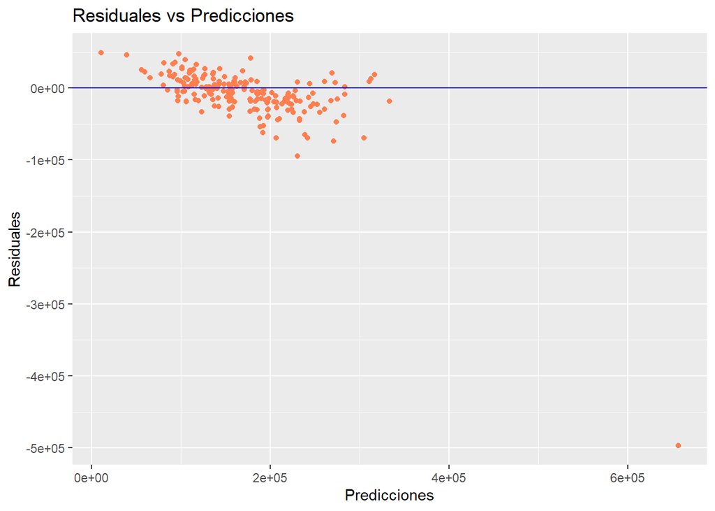

```r
## Análisis de Residuales para el Modelo Elastic Net

# Calcula los residuales
residuals_elasticnet <- y_test - y_pred_elasticnet

# 1. Residuales vs Predicciones
ggplot() +
  geom_point(aes(x=y_pred_elasticnet, y=residuals_elasticnet), color='coral') +
  geom_hline(yintercept=0, color='blue') +
  ggtitle('Residuales vs Predicciones') +
  xlab('Predicciones') +
  ylab('Residuales')
```

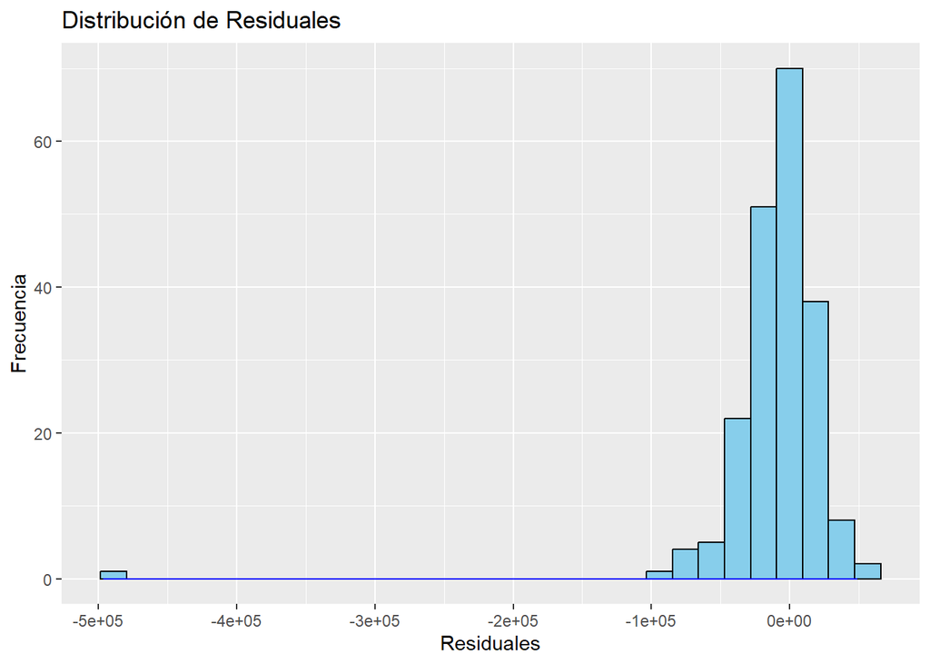

```r
# 2. Distribución de Residuales
ggplot() +
  geom_histogram(aes(x=residuals_elasticnet), bins=30, fill='skyblue', color='black') +
  geom_density(aes(x=residuals_elasticnet, y=..density..), color='blue') +
  ggtitle('Distribución de Residuales') +
  xlab('Residuales') +
  ylab('Frecuencia')
```

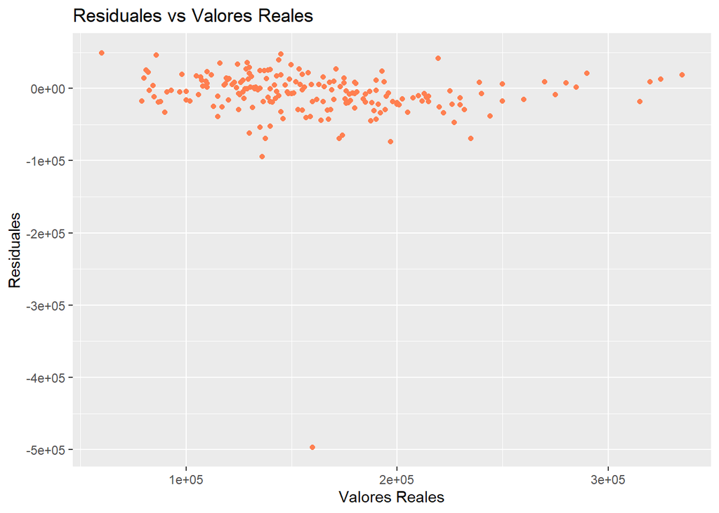

```r
# 3. Residuales vs Valores Reales
ggplot() +
  geom_point(aes(x=y_test, y=residuals_elasticnet), color='coral') +
  ggtitle('Residuales vs Valores Reales') +
  xlab('Valores Reales') +
  ylab('Residuales')
```

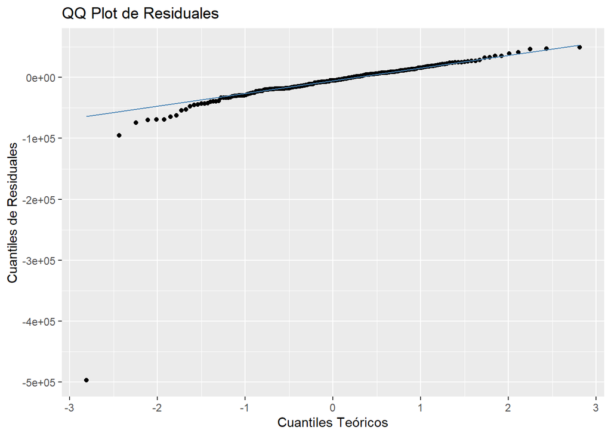

```r
# 4. QQ Plot de Residuales utilizando ggplot2
library(ggplot2)

# Asegurarse de que los residuales están en el formato correcto
residuals_elasticnet <- as.numeric(residuals_elasticnet)

# Crear un dataframe para los residuales
residuals_df_elasticnet <- data.frame(residuals = residuals_elasticnet)

# QQ Plot
ggplot(residuals_df_elasticnet, aes(sample = residuals)) +
  stat_qq() +
  stat_qq_line(color = "steelblue") +
  ggtitle("QQ Plot de Residuales") +
  xlab("Cuantiles Teóricos") +
  ylab("Cuantiles de Residuales")
```

```r
# Asumiendo que ya has calculado las métricas para cada modelo en R

models <- c('Linear Regression', 'Lasso', 'Ridge', 'ElasticNet')

# Reemplaza las variables de las métricas con los valores calculados en R para cada modelo
explained_variance <- c(explained_variance, explained_variance_lasso, explained_variance_ridge, explained_variance_elasticnet)
mean_squared_log_error <- c(mse, mse_lasso, mse_ridge, mse_elasticnet)  # Asegúrate de calcular o definir estas métricas
r2 <- c(r2, r2_lasso, r2_ridge, r2_elasticnet)
mse <- c(mse, mse_lasso, mse_ridge, mse_elasticnet)


# Imprimir las métricas para cada modelo
for (i in 1:length(models)) {
  cat("Modelo:", models[i], "\n")

  # Imprime cada métrica. Asegúrate de reemplazar 'valor_metrica_x' con tus valores reales
  cat("Explained Variance:", explained_variance[i], "\n")
  cat("Mean Squared Log Error:", mean_squared_log_error[i], "\n")
  cat("R2:",r2[i], "\n")
  cat("Mean Squared Error:", mse[i], "\n")

  cat("\n")  # Espacio extra para separar los modelos
}
```

```
## Modelo: Linear Regression
## Explained Variance: 0.8114168
## Mean Squared Log Error: 1984578743
## R2: 0.8114168
## Mean Squared Error: 1984578743
##
## Modelo: Lasso
## Explained Variance: 0.6662819
## Mean Squared Log Error: 1408570159
## R2: 0.6662819
## Mean Squared Error: 1408570159
##
## Modelo: Ridge
## Explained Variance: 0.345851
## Mean Squared Log Error: 1727507954
## R2: 0.3166692
## Mean Squared Error: 1727507954
##
## Modelo: ElasticNet
## Explained Variance: 0.3089056
## Mean Squared Log Error: 1821999309
## R2: 0.2792924
## Mean Squared Error: 1821999309
```

El modelo de Regresión Lineal es el más efectivo entre los cuatro modelos presentados. Esto se debe a que tiene el valor más alto de Varianza Explicada y R2R2, ambos a 0.8114168, indicando que es capaz de explicar aproximadamente el 81% de la variabilidad en los datos objetivo. Aunque su Error Cuadrático Medio es más alto en comparación con Lasso, las métricas de Varianza Explicada y R2R2 son más críticas para evaluar la capacidad del modelo para capturar la variación en los datos, haciéndolo preferible en este contexto.